# Simulation analysis

# Introduction

- `kallisto` results are from version 0.42.1
- `salmon` results are from version 0.3.2

This is a (re-)analysis of [Simon Cockell’s](https://github.com/sjcockell) [simulation on his blog](http://sjcockell.me/2015/05/18/alignment-free-transcriptome-quantification/) done by [Harold Pimentel](http://twitter.com/hjpimentel).

Note that [Rob Patro](http://robpatro.com/) has also done a (re-)analysis of this data (link on Simon’s Blog). There are some differences in the correlation coefficients. These are likely attributed to differences in [Pandas and R](http://stats.stackexchange.com/questions/130815/differences-in-spearman-coefficient-between-r-and-pandas).

# Preliminaries

Load packages

```r
library("dplyr")
library("sleuth")
```

Some constants

```r
# This is the default from 'polyester' (see ?polyester::simulate_experiment )
MEAN_FL <- 250.0
# small number for plotting log things
SMALL <- 1e-2
```

## Load kallisto results

```r
kal <- read_kallisto_h5("../../sim_test_kallisto/abundance.h5", FALSE)
```

## Load Salmon results

```r
all_salmon <- lapply(paste0("sim_test_salmon_", 1:10),
  function(fname)
  {
    read_salmon(file.path("..", "..", fname, "quant.sf"))
  })
```

Ensure that all samon are ordered correctly:

```r
all_salmon %>%
  lapply(function(x) all.equal(x$target_id, .[[1]]$target_id)) %>%
  unlist() %>%
  Reduce(function(x, y) x && y, .)
```

```
## [1] TRUE
```

Take averages

```r
salmon_tpm <- lapply(all_salmon, function(x) x$tpm) %>%
  as.data.frame() %>%
  apply(1, mean)
salmon_counts <- lapply(all_salmon, function(x) x$est_counts) %>%
  as.data.frame() %>%
  apply(1, mean)
salmon_avg <- data.frame(target_id = all_salmon[[1]]$target_id,
  tpm = salmon_tpm, est_counts = salmon_counts)
```

## Load oracle

Get the simulated target names

```r
transcripts <- Biostrings::readDNAStringSet("../../data/select_transcripts.fa")
transcript_names <- names(transcripts)
transcript_ids <- unlist(lapply(transcript_names,
    function(x) { substr(x, 1, 15) }))
target_ids <- data.frame(target_id = transcript_ids, stringsAsFactors = FALSE)
```

Load the oracle data and munge into a form that `sleuth` likes:

```r
oracle <- read.table("../../data/quant_bias_corrected.sf", sep="\t",
  stringsAsFactors = FALSE)
colnames(oracle) <- c("target_id", "len", "salmon_tpm", "fpkm", "counts")
oracle <- oracle %>%
  select(-c(fpkm)) %>%
  mutate(eff_len = len - MEAN_FL) %>%
  mutate(counts = round(counts))
```

The number of targets differs from the FASTA file to the number quantified against (thanks, Rob). Because of this issue, we’ll do a left join instead of an inner join.

```r
oracle <- left_join(target_ids, oracle, by = "target_id")
```

Thus, we have `NA` values for columns where it didn’t match the oracle counts.

```r
head(oracle)
```

```
##         target_id  len salmon_tpm counts eff_len
## 1 ENST00000623396   NA         NA     NA      NA
## 2 ENST00000302622 1002  0.0000000      0     752
## 3 ENST00000629937   NA         NA     NA      NA
## 4 ENST00000377996 2473  0.6632600     37    2223
## 5 ENST00000439587 2150  0.9274760     45    1900
## 6 ENST00000377991 3441  0.0457422      4    3191
```

Let’s just assign zeroes to the effective length and to the counts for the transcripts that didn’t appear in the dataset that was quantified against.

```r
oracle <- oracle %>%
  mutate(
    len = ifelse(is.na(len), 0, len),
    eff_len = ifelse(is.na(eff_len), 0, eff_len),
    counts = ifelse(is.na(counts), 0, counts)
    )
```

Sanity check to ensure we’re not getting fragments from things that have effective length <= 0:

```r
oracle %>%
  filter(counts > 0 & eff_len <= 0)
```

```
## [1] target_id  len        salmon_tpm counts     eff_len
## <0 rows> (or 0-length row.names)
```

Compute TPM from the rounded counts to get the *true* distribution. Note, this is going to be slightly different than the one read in.

```r
oracle <- oracle %>%
  mutate(tpm = counts_to_tpm(counts, eff_len),
    salmon_tpm = (salmon_tpm / sum(salmon_tpm)) * 1e6 ) %>%
  mutate(rel_diff = ifelse(tpm > 0, abs(tpm - salmon_tpm) / tpm, NA))
oracle$rel_diff %>%
  summary()
```

```
##    Min. 1st Qu.  Median    Mean 3rd Qu.    Max.    NA's
##      NA      NA      NA     NaN      NA      NA    1129
```

```r
oracle_salmon_tpm <- oracle %>%
  select(-c(tpm)) %>%
  rename(tpm = salmon_tpm)
```

```r
oracle <- oracle %>%
  select(-c(salmon_tpm, rel_diff))
```

Final sanity check:

```r
oracle %>%
  summary()
```

```
##   target_id              len            counts           eff_len
##  Length:1129        Min.   :    0   Min.   :    0.0   Min.   : -208
##  Class :character   1st Qu.:  412   1st Qu.:    0.0   1st Qu.:  162
##  Mode  :character   Median :  693   Median :    0.0   Median :  443
##                     Mean   : 1279   Mean   :  174.1   Mean   : 1076
##                     3rd Qu.: 1608   3rd Qu.:    6.0   3rd Qu.: 1358
##                     Max.   :12409   Max.   :21436.0   Max.   :12159
##       tpm
##  Min.   :     0.0
##  1st Qu.:     0.0
##  Median :     0.0
##  Mean   :   885.7
##  3rd Qu.:    76.5
##  Max.   :120417.2
```

```r
all.equal(sort(kal$abundance$target_id), sort(oracle$target_id))
```

```
## [1] TRUE
```

## Definition of error

The relative difference is defined as:

$d_i = \frac{x_i - y_i}{\frac{1}{2}\left| x_i + y_i\right|}$

where $y_i$ is the true value and $x_i$ is the estimate.

The relative error is similarly defined:

$e_i = \frac{x_i - y_i}{y_i}$

Note that the relative error is undefined when $y_i$ is zero.

```r
rel_diff <- function(x, y) {
  stopifnot(length(x) == length(y))

  result <- rep(NA_real_, length(x))

  non_zero <- which( x > 0 | y > 0 )
  both_zero <- setdiff(seq_along(x), non_zero)

  result[both_zero] <- 0.0

  result[non_zero] <- 2 * ((x[non_zero] - y[non_zero]) /
    abs(x[non_zero] + y[non_zero]))

  result
}
```

# Results

## Summarize the data using sleuth

```r
res <- merge_results(list(kal$abundance, salmon_avg), c("kallisto", "salmon_avg"), oracle)
```

`filtered_summary()` summarizes the results (comparing to oracle). When there is no filter given, it uses everything. We used this function in the `kallisto` preprint.

```r
res %>%
  filtered_summary() %>%
  lapply(print, width = 300) %>%
  invisible()
```

```
## Source: local data table [2 x 6]
##
##           method   pearson  spearman med_rel_diff_no_zeroes med_rel_diff
## 1   tpm_kallisto 0.9908756 0.8355979              0.2735451    0.0000000
## 2 tpm_salmon_avg 0.9782799 0.7932114              1.7932829    0.3392771
##   med_per_err
## 1          NA
## 2          NA
## Source: local data table [2 x 6]
##
##                  method   pearson  spearman med_rel_diff_no_zeroes
## 1   est_counts_kallisto 0.9860605 0.8360959              0.2702079
## 2 est_counts_salmon_avg 0.9768138 0.7907503              1.7907574
##   med_rel_diff med_per_err
## 1    0.0000000          NA
## 2    0.1901163          NA
```

We can use filters similar to what Rob used in his notebook.

```r
res %>%
  filtered_summary(tpm_oracle >= 0.01 & est_counts_oracle > 1) %>%
  lapply(print, width = 300) %>%
  invisible()
```

```
## Source: local data table [2 x 6]
##
##           method   pearson  spearman med_rel_diff_no_zeroes med_rel_diff
## 1   tpm_kallisto 0.9948634 0.9280120              0.1601435    0.1601435
## 2 tpm_salmon_avg 0.9812736 0.9161121              0.3765674    0.3765674
##   med_per_err
## 1   0.1522873
## 2   0.3359627
## Source: local data table [2 x 6]
##
##                  method   pearson  spearman med_rel_diff_no_zeroes
## 1   est_counts_kallisto 0.9912652 0.9350712              0.1426242
## 2 est_counts_salmon_avg 0.9825172 0.9391779              0.2161616
##   med_rel_diff med_per_err
## 1    0.1426242   0.1400430
## 2    0.2161616   0.2008727
```

## Figures

### TPM

Correlation

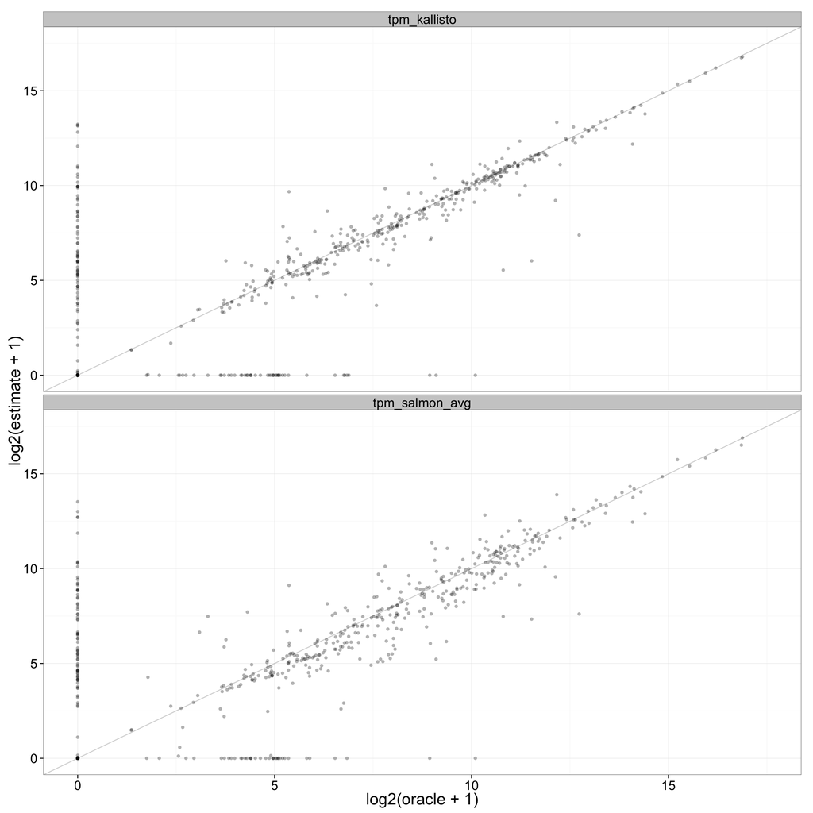

```r
ggplot(res$m_tpm, aes(log2(oracle + 1), log2(estimate + 1))) +
  geom_abline(alpha = 0.2, intercept = 0, slope = 1) +
  geom_point(alpha = 0.3) +
  theme_bw(20) +
  xlim(0, 17.5) +
  ylim(0, 17.5) +
  facet_wrap(~ method, ncol = 1)
```

Relative difference

```r
rel_diff_tpm <- res$m_tpm %>%
  group_by(method) %>%
  mutate(relative_diff = rel_diff(oracle, estimate))
```

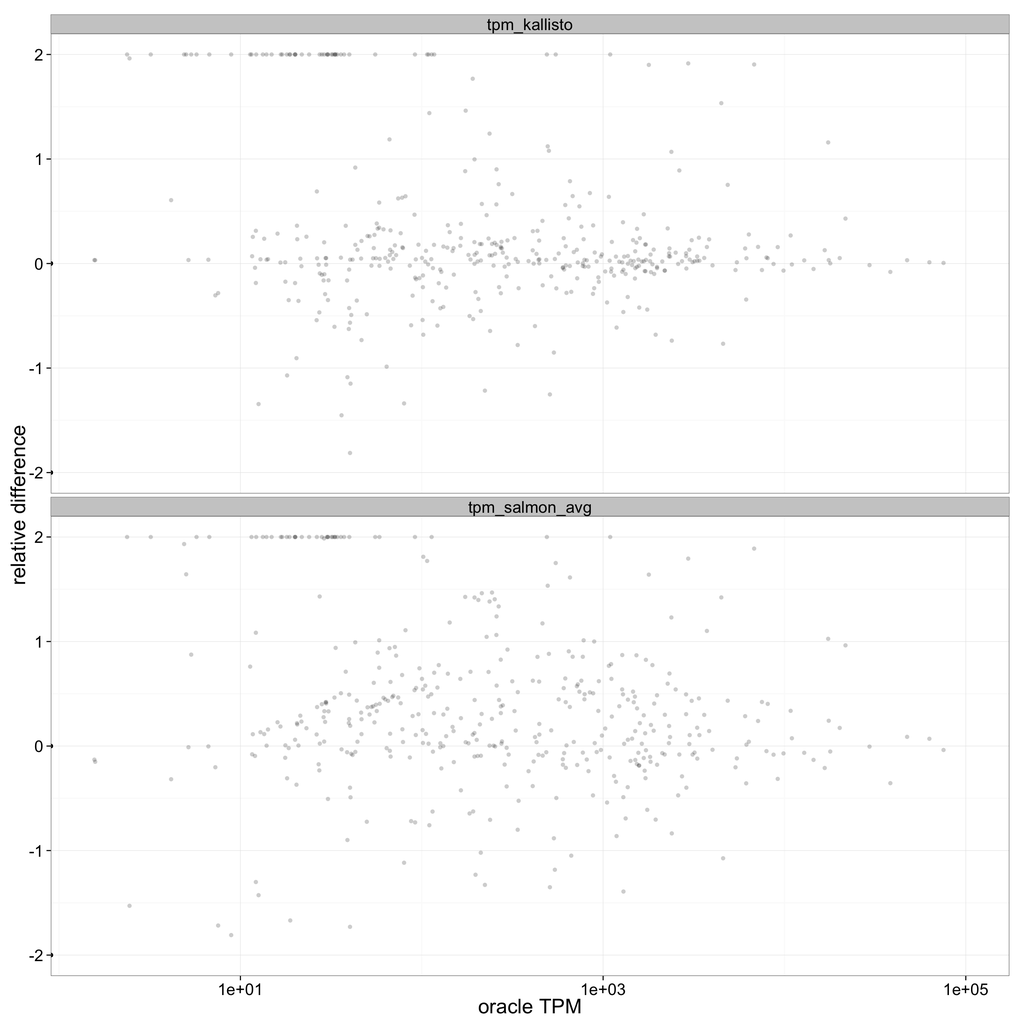

```r
ggplot(rel_diff_tpm, aes(oracle, relative_diff)) +
  geom_point(alpha = 0.2) +
  theme_bw(20) +
  scale_x_log10(limits = c(-1, 1e5)) +
  xlab("oracle TPM") +
  ylab("relative difference") +
  facet_wrap(~ method, ncol = 1)
```

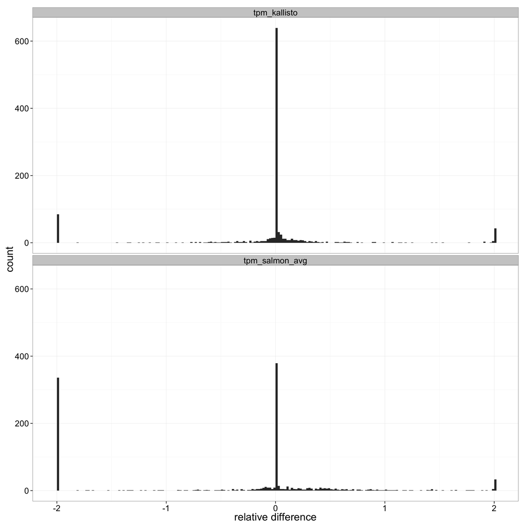

```r
ggplot(rel_diff_tpm, aes(relative_diff)) +
  geom_histogram(binwidth = 0.02) +
  theme_bw(20) +
  xlab("relative difference") +
  facet_wrap(~ method, ncol = 1)
```

### Counts

Correlation

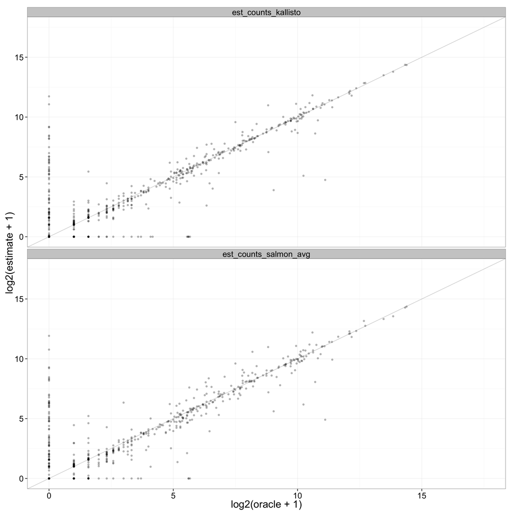

```r
ggplot(res$m_est_counts, aes(log2(oracle + 1), log2(estimate + 1))) +
  geom_abline(alpha = 0.2, intercept = 0, slope = 1) +
  geom_point(alpha = 0.3) +
  theme_bw(20) +
  xlim(0, 17.5) +
  ylim(0, 17.5) +
  facet_wrap(~ method, ncol = 1)
```

Relative difference

```r
rel_diff_est_counts <- res$m_est_counts %>%
  group_by(method) %>%
  mutate(relative_diff = rel_diff(oracle, estimate))
```

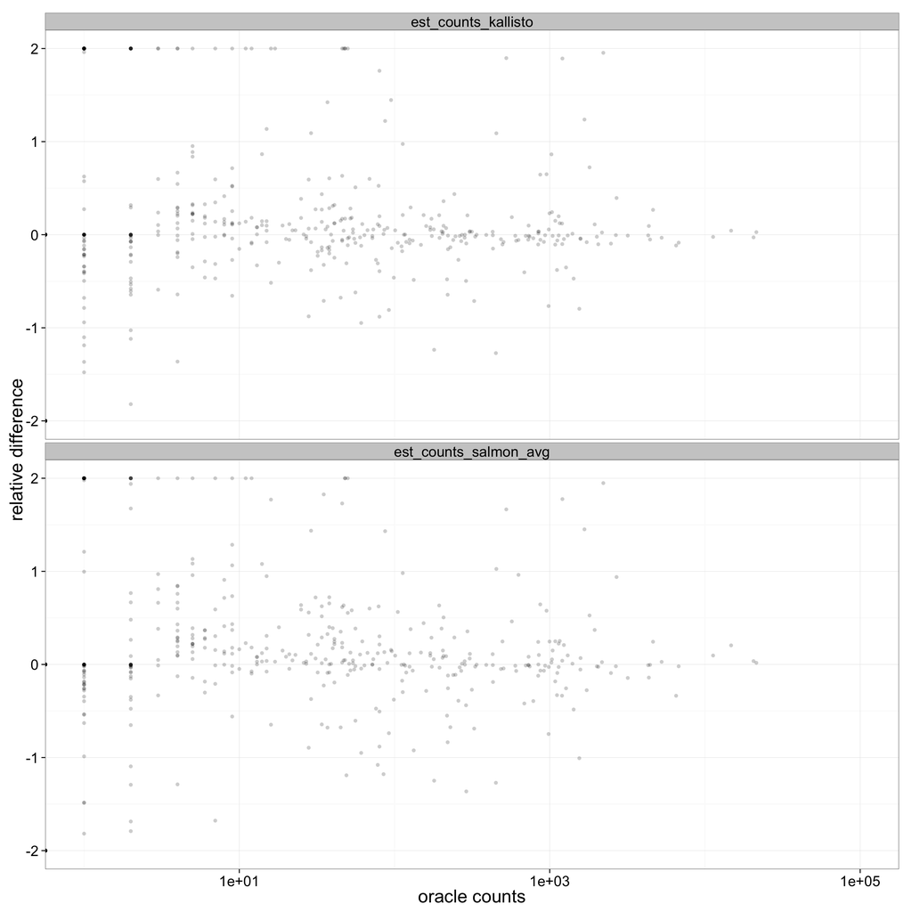

```r
ggplot(rel_diff_est_counts, aes(oracle, relative_diff)) +
  geom_point(alpha = 0.2) +
  theme_bw(20) +
  scale_x_log10(limits = c(-1, 1e5)) +
  xlab("oracle counts") +
  ylab("relative difference") +
  facet_wrap(~ method, ncol = 1)
```

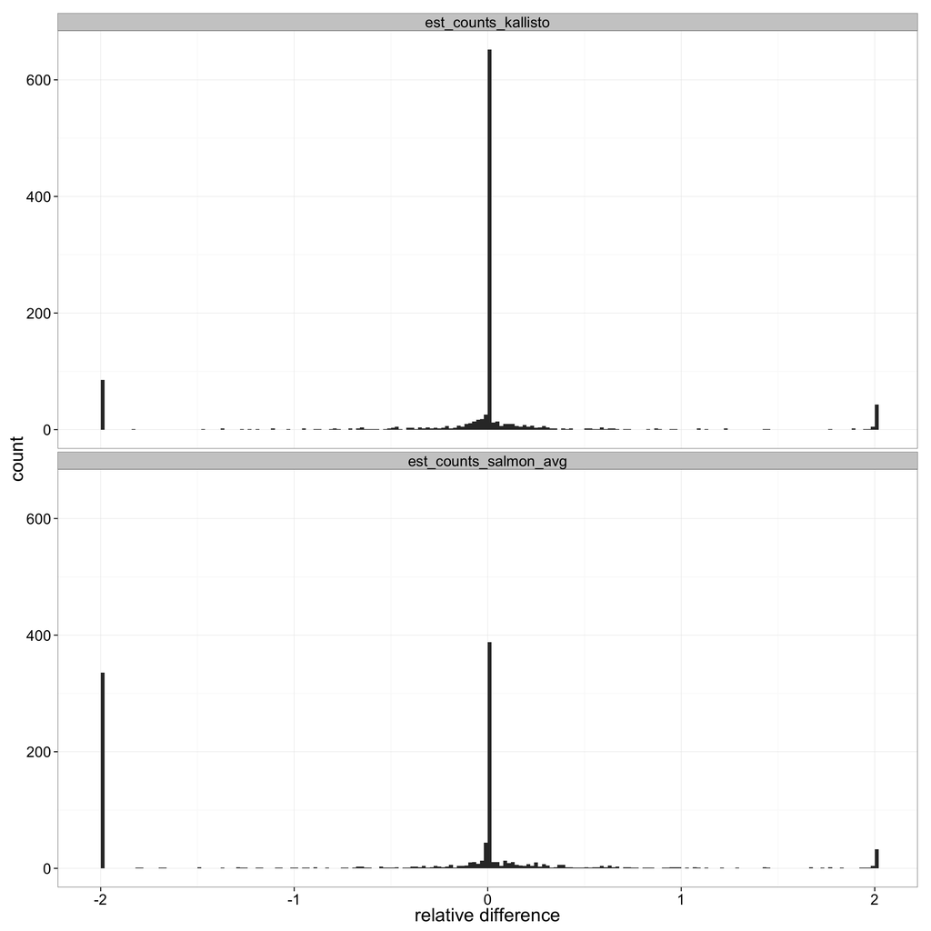

```r
ggplot(rel_diff_est_counts, aes(relative_diff)) +
  geom_histogram(binwidth = 0.02) +
  theme_bw(20) +
  xlab("relative difference") +
  facet_wrap(~ method, ncol = 1)
```

# Appendix

## Functions from sleuth

```r
sleuth::merge_results
```

```
## function (exp_list, exp_labels, oracle)
## {
##     stopifnot(is(exp_list, "list"))
##     stopifnot(length(exp_list) == length(exp_labels))
##     exp_list <- lapply(seq_along(exp_list), function(i) {
##         res <- exp_list[[i]] %>% select(target_id, tpm, est_counts) %>%
##             data.table::data.table()
##         data.table::setnames(res, "tpm", paste0("tpm_", exp_labels[i]))
##         data.table::setnames(res, "est_counts", paste0("est_counts_",
##             exp_labels[i]))
##     })
##     oracle <- oracle %>% rename(tpm_oracle = tpm, est_counts_oracle = counts)
##     all_res <- Reduce(function(x, y) inner_join(x, y, by = c("target_id")),
##         exp_list)
##     melt_by <- function(data, unit_by) {
##         m_unit <- data %>% select(target_id, starts_with(unit_by)) %>%
##             reshape2::melt(id.vars = "target_id", variable.name = "method")
##         ret <- data.table::data.table(oracle) %>% select(target_id,
##             starts_with(unit_by)) %>% inner_join(data.table::data.table(m_unit),
##             by = "target_id") %>% rename(estimate = value)
##         data.table::setnames(ret, paste0(unit_by, "_oracle"),
##             "oracle")
##         ret
##     }
##     m_tpm <- melt_by(all_res, "tpm")
##     m_est_counts <- melt_by(all_res, "est_counts")
##     all_res <- all_res %>% inner_join(data.table::data.table(oracle),
##         by = "target_id")
##     structure(list(all_data = all_res, m_tpm = m_tpm, m_est_counts = m_est_counts),
##         class = "merged_res")
## }
## <environment: namespace:sleuth>
```

```r
sleuth::filtered_summary
```

```
## function (mres, filter_exp)
## {
##     stopifnot(is(mres, "merged_res"))
##     do_filter <- if (missing(filter_exp)) {
##         FALSE
##     }
##     else {
##         filter_exp <- deparse(substitute(filter_exp))
##         filtered_ids <- mres$all_data %>% filter_(.dots = list(filter_exp)) %>%
##             select(target_id)
##         TRUE
##     }
##     both_res <- lapply(list(mres$m_tpm, mres$m_est_counts), function(res) {
##         if (do_filter) {
##             res <- data.table(res) %>% inner_join(data.table(filtered_ids),
##                 by = c("target_id"))
##         }
##         res %>% group_by(method) %>% summarise(pearson = cor(estimate,
##             oracle, method = "pearson"), spearman = cor(estimate,
##             oracle, method = "spearman"), med_rel_diff_no_zeroes = median(abs(relative_difference(estimate,
##             oracle)), na.rm = TRUE), med_rel_diff = median(abs(relative_difference(estimate,
##             oracle, FALSE))), med_per_err = median(abs(percent_error(estimate,
##             oracle))))
##     })
##     setNames(both_res, c("tpm", "est_counts"))
## }
## <environment: namespace:sleuth>
```

```r
sleuth:::relative_difference
```

```
## function (x, y, na_zeroes = TRUE)
## {
##     stopifnot(length(x) == length(y))
##     result <- rep(NA_real_, length(x))
##     non_zero <- which(x > 0 | y > 0)
##     both_zero <- setdiff(seq_along(x), non_zero)
##     if (!na_zeroes) {
##         result[both_zero] <- 0
##     }
##     result[non_zero] <- 2 * ((x[non_zero] - y[non_zero])/abs(x[non_zero] +
##         y[non_zero]))
##     result
## }
## <environment: namespace:sleuth>
```

```r
sleuth:::percent_error
```

```
## function (estimate, truth)
## {
##     (estimate - truth)/truth
## }
## <environment: namespace:sleuth>
```

```r
sleuth::read_kallisto_h5
```

```
## function (fname, read_bootstrap = TRUE)
## {
##     stopifnot(is(fname, "character"))
##     fname <- path.expand(fname)
##     if (!file.exists(fname)) {
##         stop(paste0("Can't file file: '", fname, "'"))
##     }
##     target_id <- as.character(rhdf5::h5read(fname, "aux/ids"))
##     abund <- data.frame(target_id = target_id, stringsAsFactors = FALSE)
##     abund$est_counts <- as.numeric(rhdf5::h5read(fname, "est_counts"))
##     abund$eff_len <- as.numeric(rhdf5::h5read(fname, "aux/eff_lengths"))
##     abund$len <- as.numeric(rhdf5::h5read(fname, "aux/lengths"))
##     bs_samples <- list()
##     if (read_bootstrap) {
##         num_bootstrap <- as.integer(rhdf5::h5read(fname, "aux/num_bootstrap"))
##         if (num_bootstrap > 0) {
##             cat("Found ", num_bootstrap, " bootstrap samples\n")
##             bs_samples <- lapply(0:(num_bootstrap[1] - 1), function(i) {
##                 .read_bootstrap_hdf5(fname, i, abund)
##             })
##         }
##         else {
##             cat("No bootstrap samples found\n ")
##         }
##     }
##     abund$tpm <- counts_to_tpm(abund$est_counts, abund$eff_len)
##     invisible(structure(list(abundance = abund, bootstrap = bs_samples),
##         class = "kallisto"))
## }
## <environment: namespace:sleuth>
```

```r
sleuth::read_salmon
```

```
## function (fname)
## {
##     salmon <- fread(fname, header = FALSE, skip = 13, stringsAsFactors = FALSE,
##         data.table = FALSE)
##     colnames(salmon) <- c("target_id", "length", "tpm", "fpkm",
##         "est_counts")
##     salmon %>% select(target_id, tpm, est_counts)
## }
## <environment: namespace:sleuth>
```

```r
sleuth::counts_to_tpm
```

```
## function (est_counts, eff_len)
## {
##     stopifnot(length(eff_len) == length(est_counts))
##     which_valid <- which(eff_len > 0)
##     num <- (est_counts/eff_len)
##     num[-which_valid] <- 0
##     denom <- sum(num)
##     (1e+06 * num)/denom
## }
## <environment: namespace:sleuth>
```